# Metadata Exploratory Report

Project: Differential Gene Expression and Methylation in Vaping LatinX Youth Analyst: Cheyret Wood ; Trent Hawkins Investigator(s): Sunita Sharma, MD Report generated: February 25, 2022

# 1 Background

The data presented in this report are part of a study aimed to assess differential gene expression and methylation in vaping versus non-vaping LatinX youths in Pueblo and Denver, CO. Pulmonary function data were also obtained in order to better understand the impacts of vape use on pulmonary function.

# 2 Study Population

This data set consists of samples taken from 51 people ages 12-17 from the Pueblo, CO and the Denver-metro area. Subjects were asked to identify as ‘Latino’ or ‘Non-latino’.

# 3 Methods

To assess differential gene expression and methylation, naso-epithelial swabs were obtained from each participating subject. Pulmonary function is assessed using PFTs (Pulmonary Function Tests).

# 4 Descriptive Statistics

*Table 1: Clinical Data*

```r
#import data
table1_dat <- read_csv(here("DataProcessed/metadata_cleaning/table1_clean_data_2022_02_25.csv"))

table1_dat$grade <-ordered(table1_dat$grade,levels = c('7th', '8th','Freshman','Sophomore','Junior','Senior'))

table1_dat <- table1_dat %>%
  filter(!is.na(vape_6mo_lab))
#create table 1
vape_6mo_table1 <- tableby(vape_6mo_lab ~ sex_lab + age + grade +
                           city + latino_lab + fev1_fvc + r5 + x20,
                           data = table1_dat, digits = 1)

#Fix Labels
labels(vape_6mo_table1) <- c(vape_6mo_lab = "Vaped in last 6 months",
                             age = "Age", sex_lab = "Gender", city = "City",
                             latino_lab = "Race", grade = "Grade",
                             fev1_fvc = "FEV1/FVC", r5 = 'R5', x20 = 'X20')

#Print Tables
summary(vape_6mo_table1, pfootnote = T)
```

|  | Did Not Vape in Last 6 Months (N=37) | Vaped in Last 6 Months (N=13) | Total (N=50) | p value |
| --- | --- | --- | --- | --- |
| **Gender** |  |  |  | 0.475<sup>1</sup> |
| Female | 20 (54.1%) | 5 (38.5%) | 25 (50.0%) |  |
| Male | 16 (43.2%) | 8 (61.5%) | 24 (48.0%) |  |
| Non-Binary | 1 (2.7%) | 0 (0.0%) | 1 (2.0%) |  |
| **Age** |  |  |  | 0.663<sup>2</sup> |
| Mean (SD) | 14.6 (1.4) | 14.8 (1.4) | 14.6 (1.4) |  |
| Range | 12.0 - 17.0 | 13.0 - 17.0 | 12.0 - 17.0 |  |
| **Grade** |  |  |  | 0.457<sup>3</sup> |
| 7th | 3 (8.1%) | 0 (0.0%) | 3 (6.0%) |  |
| 8th | 8 (21.6%) | 4 (30.8%) | 12 (24.0%) |  |
| Freshman | 14 (37.8%) | 3 (23.1%) | 17 (34.0%) |  |
| Sophomore | 4 (10.8%) | 2 (15.4%) | 6 (12.0%) |  |
| Junior | 4 (10.8%) | 2 (15.4%) | 6 (12.0%) |  |
| Senior | 4 (10.8%) | 2 (15.4%) | 6 (12.0%) |  |
| **City** |  |  |  | < 0.001<sup>1</sup> |
| Aurora | 15 (40.5%) | 0 (0.0%) | 15 (30.0%) |  |
| Aurora/ Trujillo Colon | 1 (2.7%) | 0 (0.0%) | 1 (2.0%) |  |
| Avondale | 1 (2.7%) | 0 (0.0%) | 1 (2.0%) |  |
| Commerce City | 7 (18.9%) | 0 (0.0%) | 7 (14.0%) |  |
| Denver | 4 (10.8%) | 0 (0.0%) | 4 (8.0%) |  |
| Mineral Wells | 1 (2.7%) | 0 (0.0%) | 1 (2.0%) |  |
| Pueblo | 8 (21.6%) | 12 (92.3%) | 20 (40.0%) |  |
| Thornton | 0 (0.0%) | 1 (7.7%) | 1 (2.0%) |  |
| **Race** |  |  |  | 0.135<sup>1</sup> |
| Latino | 23 (62.2%) | 11 (84.6%) | 34 (68.0%) |  |
| Non-Latino | 14 (37.8%) | 2 (15.4%) | 16 (32.0%) |  |
| **FEV1/FVC** |  |  |  | 0.494<sup>2</sup> |
| N-Miss | 10 | 12 | 22 |  |
| Mean (SD) | 0.8 (0.1) | 0.7 (NA) | 0.8 (0.1) |  |
| Range | 0.5 - 1.0 | 0.7 - 0.7 | 0.5 - 1.0 |  |
| **R5** |  |  |  | 0.007<sup>2</sup> |
| N-Miss | 1 | 0 | 1 |  |
| Mean (SD) | 4.0 (0.9) | 5.0 (1.3) | 4.3 (1.1) |  |
| Range | 2.0 - 6.1 | 3.7 - 7.6 | 2.0 - 7.6 |  |
| **X20** |  |  |  | 0.007<sup>2</sup> |
| N-Miss | 4 | 2 | 6 |  |
| Mean (SD) | 0.1 (0.6) | 0.7 (0.9) | 0.2 (0.7) |  |
| Range | -1.1 - 2.4 | -1.0 - 2.3 | -1.1 - 2.4 |  |

1. Pearson’s Chi-squared test
2. Linear Model ANOVA
3. Trend test for ordinal variables

## 4.1 Figures

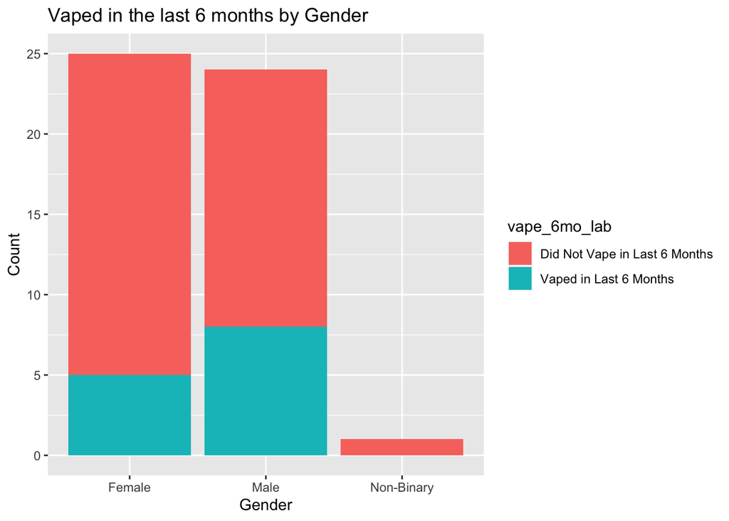

```r
#By Gender
bar_gender <- table1_dat %>%
  ggplot(aes(x = sex_lab, fill = vape_6mo_lab)) +
  geom_bar() +
  labs(x = "Gender", y = "Count") +
  ggtitle("Vaped in the last 6 months by Gender")
#By Latino
bar_latino <- table1_dat %>%
  ggplot(aes(x = latino_lab, fill = vape_6mo_lab))+
  geom_bar()+
  labs(x = "Ethnicity", y = "Count") +
  ggtitle("Vaped in the last 6 months by Latino")

#By FEV1/FVC Continuous
hist_fev1_fvc <- table1_dat %>%
  ggplot(aes(x = fev1_fvc, fill = vape_6mo_lab))+
  geom_histogram(binwidth = 0.1, color = 'black', breaks = seq(0.5,1,0.1))+
  labs(x = TeX("\\frac{FEV1}{FVC}"), y = "Count") +
  xlim(0.5,1) +
  ggtitle(TeX("\\frac{FEV1}{FVC} \ by Vape Status"))

#By FEV1/FVC Box
box_fev1_fvc <- table1_dat %>%
  ggplot(aes(x = vape_6mo_lab, y = fev1_fvc, fill = vape_6mo_lab)) +
  geom_boxplot(show.legend = F) +
  labs(x = "Vape Status", y = TeX("\\frac{FEV1}{FVC}")) +
  ggtitle("R5 by Vape Status (n = 49)")

#By R5(hist)
r5_hist <- table1_dat %>%
  ggplot(aes(x = r5, fill = vape_6mo_lab)) +
  geom_histogram(binwidth = 1, color = 'black', breaks = seq(1,8,1)) +
  labs(x = TeX("\\frac{FEV1}{FVC}"), y = "Count") +
  xlim(1,8) +
  ggtitle("R5 by Vape Status (n = 49)")

#by R5(box)
r5_box <- table1_dat %>%
  ggplot(aes(x = vape_6mo_lab, y = r5, fill = vape_6mo_lab)) +
  geom_boxplot(show.legend = F) +
  labs(x = "Vape Status", y = "R5") +
  ggtitle("R5 by Vape Status (n = 49)")

#by X20(box)
x20_box <- table1_dat %>%
  ggplot(aes(x = vape_6mo_lab, y = x20, fill = vape_6mo_lab)) +
  geom_boxplot(show.legend = F) +
  labs(x = "Vape Status", y = "X20") +
  ggtitle("X20 by Vape Status (n = 44)")

#by x20(his)
x20_hist <- table1_dat %>%
  ggplot(aes(x = x20, fill = vape_6mo_lab)) +
  geom_histogram(color = "Black", bins = 10, breaks = seq(-1.5,2.5,.5)) +
  labs(x = 'X20', y = "Count") +
  ggtitle("X20 by Vape Status (n = 44)")

bar_gender
```

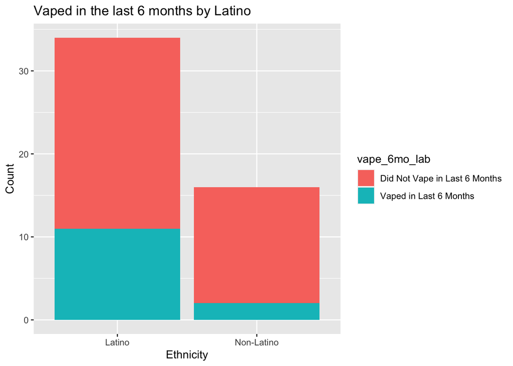

```r
bar_latino
```

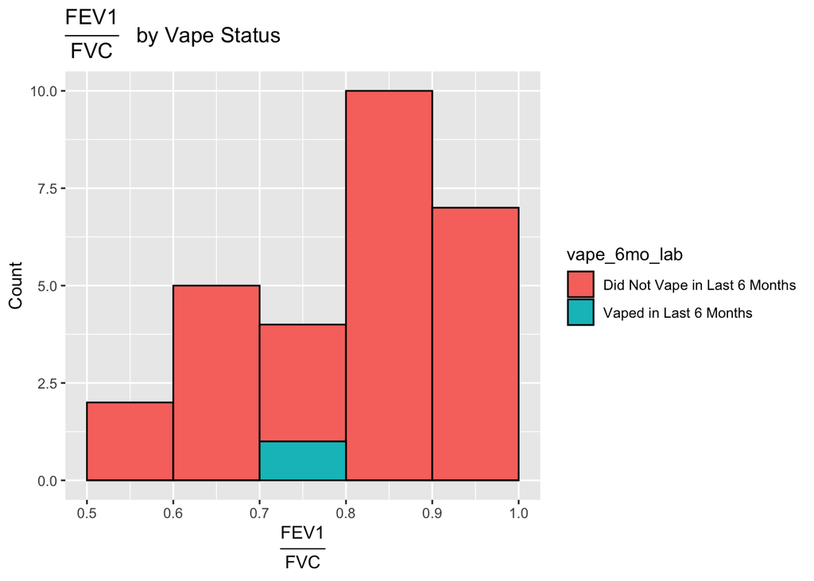

```r
hist_fev1_fvc
```

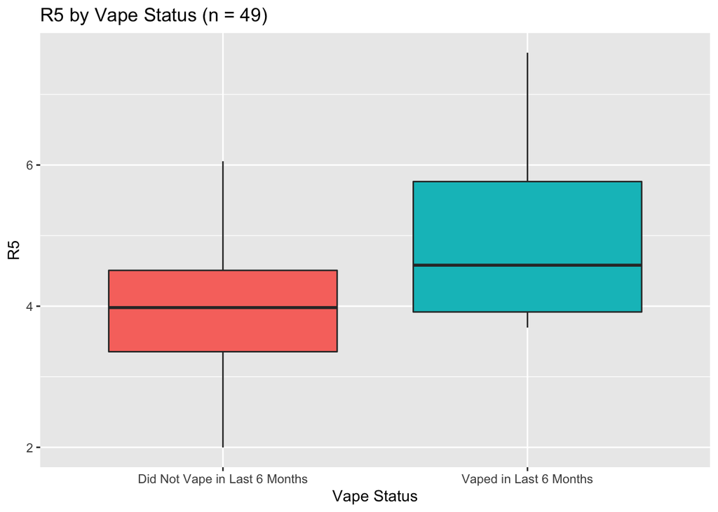

```r
r5_box
```

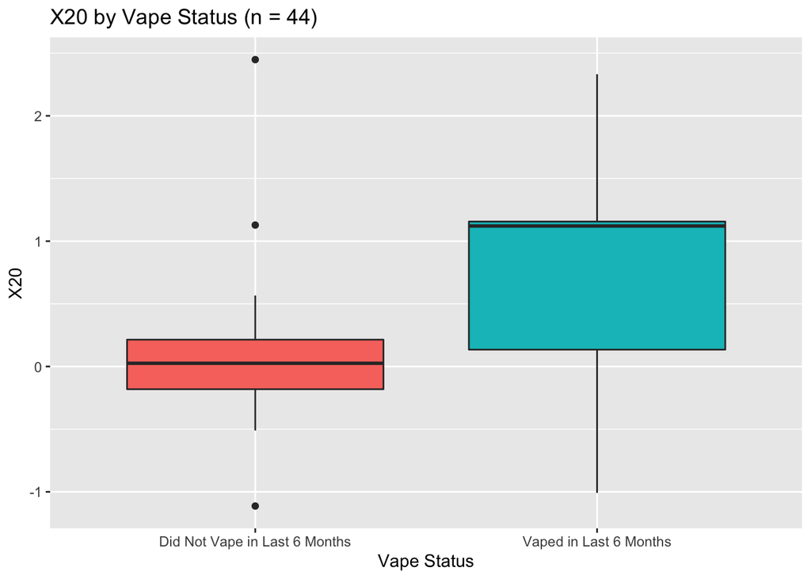

```r
x20_box
```

# 5 Notes

- We are in the process of going through Cuining’s old files and have yet to verify the status of the ‘vaping’ variables. We cannot yet confirm that ‘vaped in the last 6 months’, ‘vaped in the last 30 days’, or ‘ever vaped’ are accurate.

# 6 Questions

- Most of the varialbes collected in the dataset seem to be addressing Aim 1. Do you have any thoughts about how you would like to structure this analysis? Any idea which variables will help us best target this aim?
- Aim 2 looks at the impact of vape use on respiratory outcomes. What variables would be best to use as the response variable for each of the measures mentioned below, and how do you expect those variables to react in the exposed group?
  - Lung function
  - Impulse Oscillometry
  - Exhaled Nitric Oxide
- Is there a more raw version of the survey data that we could use to verify Choo’s output?

## 6.1 Data structure and issues

The following is my understanding of how the vaping variable is structured:

- Question 1: “Have you ever used any of the following, even just one or two times?”
  - ever_vape (yes or no) determined based on response to this question
  - From Choo’s output: if the participant did not answer this question, then they had never tried vaping
  - Issue is that there is an option for “never tried” in this question.
- Question 2: “How many times have you vaped in the last 30 days”
  - Created “Have you vaped in the last 30 days? (yes or no)” based on response to this question
  - This method groups individuals who have vaped every day in the last 30 days with individuals who vaped once in the last 30 days.
- Question 3: “When was the last time you used a vape device, even one or two times?”
  - “Have you vaped in the last 6 months? (yes or no)” based on response to this question